# Food-related attentional bias and its associations with appetitive motivation and body weight: A systematic review and meta-analysis - ScienceDirect

## Figures (2)

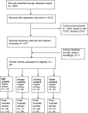

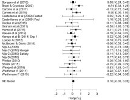

## Tables (1)

1. Table 1

## [Appetite](https://www.sciencedirect.com/science/journal/01956663)

[Volume 157](https://www.sciencedirect.com/science/journal/01956663/157/supp/C), 1 February 2021, 104986

# Research review Food-related attentional bias and its associations with appetitive motivation and body weight: A systematic review and meta-analysis

[Charlotte A.Hardman<sup>a</sup>](https://www.sciencedirect.com/science/article/abs/pii/S0195666320316081#!)[AndrewJones<sup>a</sup>](https://www.sciencedirect.com/science/article/abs/pii/S0195666320316081#!)[SamBurton<sup>a</sup>](https://www.sciencedirect.com/science/article/abs/pii/S0195666320316081#!)[Jay J.Duckworth<sup>a</sup>](https://www.sciencedirect.com/science/article/abs/pii/S0195666320316081#!)[Lauren S.McGale<sup>a</sup><sup>b</sup>](https://www.sciencedirect.com/science/article/abs/pii/S0195666320316081#!)[Bethan R.Mead<sup>a</sup>](https://www.sciencedirect.com/science/article/abs/pii/S0195666320316081#!)[Carl A.Roberts<sup>a</sup>](https://www.sciencedirect.com/science/article/abs/pii/S0195666320316081#!)[MattField<sup>c</sup>](https://www.sciencedirect.com/science/article/abs/pii/S0195666320316081#!)[JessicaWerthmann<sup>d</sup><sup>e</sup>](https://www.sciencedirect.com/science/article/abs/pii/S0195666320316081#!)

https://doi.org/10.1016/j.appet.2020.104986[Get rights and content](https://s100.copyright.com/AppDispatchServlet?publisherName=ELS&contentID=S0195666320316081&orderBeanReset=true)

## Abstract

Theoretical models suggest that food-related visual attentional bias (AB) may be related to appetitive motivational states and individual differences in body weight; however, findings in this area are equivocal. We conducted a systematic review and series of meta-analyses to determine if there is a positive association between food-related AB and: (1.) body mass index (BMI) (number of effect sizes (*k*) = 110), (2.) hunger (*k* = 98), (3.) subjective craving for food (*k* = 35), and (4.) food intake (*k* = 44). Food-related AB was robustly associated with craving (*r* = 0.134 (95% CI 0.061, 0.208); *p* < .001), food intake (*r* = 0.085 (95% CI 0.038, 0.132); *p* < .001), and hunger (*r* = 0.048 (95% CI 0.016, 0.079); *p* = .003), but these correlations were small. Food-related AB was unrelated to BMI (*r* = 0.008 (95% CI -0.020, 0.035); *p* = .583) and this result was not moderated by type of food stimuli, method of AB assessment, or the subcomponent of AB that was examined. Furthermore, in a between-groups analysis (*k* = 22) which directly compared participants with overweight/obesity to healthy-weight control groups, there was no evidence for an effect of weight status on food-related AB (Hedge's g = 0.104, (95% CI -0.050, 0.258); *p* = .186). Taken together, these findings suggest that food-related AB is sensitive to changes in the motivational value of food, but is unrelated to individual differences in body weight. Our findings question the traditional view of AB as a trait-like index of preoccupation with food and have implications for novel theoretical perspectives on the role of food AB in appetite control and obesity.

## Keywords

Attentional bias

Appetite

Eating

Body weight

Craving

Hunger

Motivation

Incentive value

Executive function